# Avanced structural equation modeling

9.11.2022

# Load data and re-run the model

Here, we use the very same data set as in the introductory part to SEM (`1_basic_modeling.html`). Also, we rescale the biomass and precipitation so that they are in approximately the same range as the other variables.

```r
seabloom <- read.table(here("2_Modeling/Data_preparation/seabloom-2020-ele-dryad-data/cdr-e001-e002-output-data.csv"),
                       sep = ",", header = TRUE)

seabloom$mass.above <- seabloom$mass.above / 100
seabloom$precip.mm <- seabloom$precip.mm / 100
seabloom$precip.gs <- seabloom$precip.gs / 100
```

## Rerun the model

First, we run the model as before.

[figure not shown]

```r
library("lavaan")
simple <-
"mass.above ~ nadd + disk + rich + even + precip.mm
rich ~ nadd + precip.mm
even ~ nadd + precip.mm

rich ~~ even"

fit.simple <- sem(simple, data = seabloom, estimator = "MLM")
summary(fit.simple)
```

```
## lavaan 0.6-12 ended normally after 30 iterations
##
##   Estimator                                         ML
##   Optimization method                           NLMINB
##   Number of model parameters                        13
##
##   Number of observations                          5040
##
## Model Test User Model:
##                                               Standard      Robust
##   Test Statistic                                 6.684       6.573
##   Degrees of freedom                                 2           2
##   P-value (Chi-square)                           0.035       0.037
##   Scaling correction factor                                  1.017
##     Satorra-Bentler correction
##
## Parameter Estimates:
##
##   Standard errors                           Robust.sem
##   Information                                 Expected
##   Information saturated (h1) model          Structured
##
## Regressions:
##                    Estimate  Std.Err  z-value  P(>|z|)
##   mass.above ~
##     nadd              0.085    0.003   29.463    0.000
##     disk              0.424    0.037   11.453    0.000
##     rich              0.086    0.006   14.620    0.000
##     even             -0.651    0.115   -5.673    0.000
##     precip.mm         0.099    0.011    9.390    0.000
##   rich ~
##     nadd             -0.186    0.005  -34.433    0.000
##     precip.mm         0.393    0.028   14.120    0.000
##   even ~
##     nadd              0.005    0.000   14.879    0.000
##     precip.mm        -0.023    0.002  -12.950    0.000
##
## Covariances:
##                    Estimate  Std.Err  z-value  P(>|z|)
##  .rich ~~
##    .even             -0.416    0.010  -39.971    0.000
##
## Variances:
##                    Estimate  Std.Err  z-value  P(>|z|)
##    .mass.above        1.669    0.058   28.652    0.000
##    .rich             13.334    0.298   44.791    0.000
##    .even              0.040    0.001   41.672    0.000
```

# Latent and composite variables

**Latent variables** represent unmeasured variables that are represented by their indicator variables[^1] (Bollen 1989). As a consequence, a latent variable is free of random or systematic measurement errors in contrast to its indicators (Bollen 1989). They have a special role in SEM because they represent a kind of bridge between observed data and theoretical generalization (James B. Grace and Bollen 2008).

Usually, they are visualized by arrows pointing from the latent variable to the indicators (so-called “reflective” (James B. Grace 2021)). This symbolizes the underlying process that generated the indicators. In other words, latent variables give rise to their indicators. Often, ellipses are used to denote a latent variable.

**Composites** are another type of variables which represent the collective effects of a set of causes on some response variable(s) (James B. Grace and Bollen 2008). In comparison to latent variables, they arise from the indicators. For this reason, they are visualized by arrows pointing from the indicators to the composite (so-called “formative” (James B. Grace 2021) or “causal indicators” (James B. Grace et al. 2010)). In that respect, they represent a collective effect (e.g., the collective effect of the abiotic environment). Since its values are determined by its causes (indicators), the error variance is specified to be 0 (James B. Grace and Bollen 2008). Thus, they are technically latent variables without variance (James B. Grace 2021). Composites are often symbolized by hexangular shapes or–the same as for latent variables–by ellipses.

**Key differences** between them are (James B. Grace and Bollen 2008):

1. The flow of causation in a latent variables is from the construct to its indicators, meaning that the indicators are driven by an underlying, unmeasured process, the latent variable. In the case of a composite variable, the flow of causation is reversed and the indicators are independent entities no matter the construct.
2. If the indicators are redundant, they likely belong to a latent variable. If the meaning of the construct changes after dropping one of the indicators, the construct likely is a composite.
3. As a latent variable represents an underlying, data-generating process, its indicators need to be correlated to each other. In the case of a composite variable, there is no assumption about the relation between the indicators. Thus, correlation among indicators are uninformative about the direction of the causal flow, but a lack of such contraindicates that the construct is a latent variable.

Carried over to our example, we measured instances of the general process “diversity” (richness, evenness etc.). Further, we summarize the abiotic condition (nutrient addition, precipitation etc.) of a plot in a composite variable.

[figure not shown]

# Latent variable

Let’s first create a latent variable “diversity” from the three measurements of diversity (richness, evenness and ENS<sub>PIE</sub>).

Latent variable models are usually evaluated in two stages: first the fit between the latent variables and their indicators ([confirmatory factor analysis (CFA)](https://en.wikipedia.org/wiki/Confirmatory_factor_analysis)), second the full model (James B. Grace and Steiner 2021).

## Correlations between indicators

Indicators for a LV should be positively correlated with each other. If we fail to find significant correlations based on standard tests and null hypothesis testing, we reject the hypothesis that the indicators are varying in concert and the data contradicts the claim of a latent cause (James B. Grace and Steiner 2021).

```r
cor.test(seabloom$even, seabloom$rich)
```

```
##
##  Pearson's product-moment correlation
##
## data:  seabloom$even and seabloom$rich
## t = -55.464, df = 5038, p-value < 2.2e-16
## alternative hypothesis: true correlation is not equal to 0
## 95 percent confidence interval:
##  -0.6325776 -0.5982835
## sample estimates:
##       cor
## -0.615722
```

```r
cor.test(seabloom$ens.pie, seabloom$rich)
```

```
##
##  Pearson's product-moment correlation
##
## data:  seabloom$ens.pie and seabloom$rich
## t = 57.95, df = 5038, p-value < 2.2e-16
## alternative hypothesis: true correlation is not equal to 0
## 95 percent confidence interval:
##  0.6155705 0.6487132
## sample estimates:
##       cor
## 0.6324312
```

```r
cor.test(seabloom$even, seabloom$ens.pie)
```

```
##
##  Pearson's product-moment correlation
##
## data:  seabloom$even and seabloom$ens.pie
## t = -0.16074, df = 5038, p-value = 0.8723
## alternative hypothesis: true correlation is not equal to 0
## 95 percent confidence interval:
##  -0.02987178  0.02534607
## sample estimates:
##         cor
## -0.00226458
```

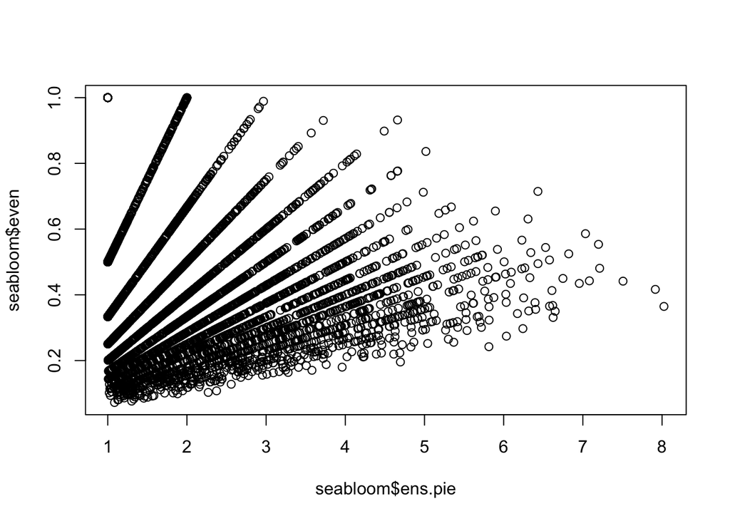

```r
## Not that surprising that there is no correlation...
plot(seabloom$ens.pie, seabloom$even)
```

To ease convergence of the algorithm, we reverse the orientation of evenness as it is negatively correlated with richness (so that absolute evenness is found at 0, while absolute unevenness is found at 1):

```r
seabloom$even.rev <- 1 - seabloom$even
cor.test(seabloom$even.rev, seabloom$rich)
```

```
##
##  Pearson's product-moment correlation
##
## data:  seabloom$even.rev and seabloom$rich
## t = 55.464, df = 5038, p-value < 2.2e-16
## alternative hypothesis: true correlation is not equal to 0
## 95 percent confidence interval:
##  0.5982835 0.6325776
## sample estimates:
##      cor
## 0.615722
```

```r
cor.test(seabloom$ens.pie, seabloom$even.rev)
```

```
##
##  Pearson's product-moment correlation
##
## data:  seabloom$ens.pie and seabloom$even.rev
## t = 0.16074, df = 5038, p-value = 0.8723
## alternative hypothesis: true correlation is not equal to 0
## 95 percent confidence interval:
##  -0.02534607  0.02987178
## sample estimates:
##        cor
## 0.00226458
```

## Confirmatory factor analysis

Let’s start with the CFA:

```r
diversity <- 'div =~ rich + even.rev + ens.pie'

fit.diversity <- cfa(diversity, data = seabloom, estimator = "MLM")
summary(fit.diversity, standardized=T, rsq=T)
```

```
## lavaan 0.6-12 ended normally after 897 iterations
##
##   Estimator                                         ML
##   Optimization method                           NLMINB
##   Number of model parameters                         6
##
##   Number of observations                          5040
##
## Model Test User Model:
##                                               Standard      Robust
##   Test Statistic                                 0.000       0.000
##   Degrees of freedom                                 0           0
##
## Parameter Estimates:
##
##   Standard errors                           Robust.sem
##   Information                                 Expected
##   Information saturated (h1) model          Structured
##
## Latent Variables:
##                    Estimate   Std.Err  z-value  P(>|z|)   Std.lv   Std.all
##   div =~
##     rich               1.000                               53.240   13.113
##     even.rev           0.000       NA                       0.010    0.047
##     ens.pie            0.001       NA                       0.054    0.048
##
## Variances:
##                    Estimate   Std.Err  z-value  P(>|z|)   Std.lv   Std.all
##    .rich           -2817.961       NA                   -2817.961 -170.951
##    .even.rev           0.043       NA                       0.043    0.998
##    .ens.pie            1.269       NA                       1.269    0.998
##     div             2834.445       NA                       1.000    1.000
##
## R-Square:
##                    Estimate
##     rich                  NA
##     even.rev           0.002
##     ens.pie            0.002
```

```r
varTable(fit.diversity)
```

```
##       name idx nobs    type exo user  mean    var nlev lnam
## 1     rich  14 5040 numeric   0    0 6.761 16.487    0
## 2 even.rev  17 5040 numeric   0    0 0.595  0.043    0
## 3  ens.pie  16 5040 numeric   0    0 2.220  1.272    0
```

Parameter estimates taking improper solution, i.e. impossible values, are a sign of model misspecification. The occurrence of negative variances, as we see here, is known as “Heywood case”. Another improper solution would be correlations larger than one (Bollen 1989). Reasons for the current warning could be (i) slightly negative error estimates (what would not really be a problem), (ii) the need to code indicators for the latent variable to be positively related, (iii) local non-identification or (iv) general misspecification (James B. Grace 2021).

Here we clearly have a problem with model mis-specification. According to (Seabloom, Borer, and Tilman (2020)), the variable ens.pie is the product of evenness and species richness. This causes the model to fail. Therefore let’s abandon the ens.pie variable for a moment and focus on a two indicator latent variable.

Latent variable models with only 2 indicators are locally non-identified because we only have one piece of information (their correlation) to estimate two path coefficients. To solve this problem, we can (a) ensure x1 and x2 have equal variances, in this case by standardizing the data. (2) When latent variables are included we must specify a fixed value for some parameter associated with the LV to achieve identification. The lavaan default is to set the loading from the LV to the first-mentioned indicator to 1.0. (3) For single-indicator LVs, the default measurement error is set to 0.0 (James B. Grace 2021).

Here we standardize the two variables and then estimate a single path coefficient by forcing a single coefficient for both indicators:

```r
seabloom$rich_std <- (mean(seabloom$rich)-seabloom$rich) / sd(seabloom$rich)
seabloom$even.rev_std <- (mean(seabloom$even.rev)-seabloom$even.rev) / sd(seabloom$even.rev)

diversity <- 'div =~ lambda*rich_std + lambda*even.rev_std'

fit.diversity <- cfa(diversity, data = seabloom, estimator = "MLM")
summary(fit.diversity, standardized=T)
```

```
## lavaan 0.6-12 ended normally after 12 iterations
##
##   Estimator                                         ML
##   Optimization method                           NLMINB
##   Number of model parameters                         3
##
##   Number of observations                          5040
##
## Model Test User Model:
##                                               Standard      Robust
##   Test Statistic                                 0.000       0.000
##   Degrees of freedom                                 0           0
##
## Parameter Estimates:
##
##   Standard errors                           Robust.sem
##   Information                                 Expected
##   Information saturated (h1) model          Structured
##
## Latent Variables:
##                    Estimate  Std.Err  z-value  P(>|z|)   Std.lv  Std.all
##   div =~
##     rch_std (lmbd)    1.000                               0.785    0.785
##     evn.rv_ (lmbd)    1.000                               0.785    0.785
##
## Variances:
##                    Estimate  Std.Err  z-value  P(>|z|)   Std.lv  Std.all
##    .rich_std          0.384    0.018   21.808    0.000    0.384    0.384
##    .even.rev_std      0.384    0.015   25.194    0.000    0.384    0.384
##     div               0.616    0.015   42.153    0.000    1.000    1.000
```

This worked, all variances are positive and we get a single coefficient for the effects of diversity on richness and evenness. As the model is just identified, we do not have a possibility to test model fit.

## Full model

Now, let’s evaluate the full model including the latent variable as well as the remaining variables.

```r
lv <- '
# Latent variable definition
diversity =~ lambda*even.rev_std + lambda*rich_std

mass.above ~ nadd + disk + diversity + precip.mm
diversity ~ nadd + precip.mm
'

fit.lv <- sem(lv, data = seabloom, estimator = "MLM")
summary(fit.lv)
```

```
## lavaan 0.6-12 ended normally after 27 iterations
##
##   Estimator                                         ML
##   Optimization method                           NLMINB
##   Number of model parameters                        10
##
##   Number of observations                          5040
##
## Model Test User Model:
##                                               Standard      Robust
##   Test Statistic                               223.092     219.836
##   Degrees of freedom                                 5           5
##   P-value (Chi-square)                           0.000       0.000
##   Scaling correction factor                                  1.015
##     Satorra-Bentler correction
##
## Parameter Estimates:
##
##   Standard errors                           Robust.sem
##   Information                                 Expected
##   Information saturated (h1) model          Structured
##
## Latent Variables:
##                    Estimate  Std.Err  z-value  P(>|z|)
##   diversity =~
##     evn.rv_ (lmbd)    1.000
##     rch_std (lmbd)    1.000
##
## Regressions:
##                    Estimate  Std.Err  z-value  P(>|z|)
##   mass.above ~
##     nadd              0.091    0.003   29.918    0.000
##     disk              0.428    0.037   11.541    0.000
##     diversity        -0.675    0.032  -20.812    0.000
##     precip.mm         0.079    0.011    7.230    0.000
##   diversity ~
##     nadd              0.038    0.001   28.059    0.000
##     precip.mm        -0.102    0.007  -15.293    0.000
##
## Variances:
##                    Estimate  Std.Err  z-value  P(>|z|)
##    .even.rev_std      0.448    0.013   33.586    0.000
##    .rich_std          0.320    0.015   21.233    0.000
##    .mass.above        1.611    0.057   28.485    0.000
##    .diversity         0.486    0.012   39.164    0.000
```

The model converged, but the model fit is not great. The coefficients suggest effects of nutrient addition and precipitation on diversity. However, we would expect a negative effect of nutrient addition, while the effect is positive. The opposite expectation would hold for precipitation, but here we see a negative effect. Can you explain why this is the case?

Right, it has to do with reversing the direction of the evenness effect. As both richness and reversed evenness influence AGB, the meaning of the latent diversity effect is reversed. We can see this when we fit a model that just contains the ens.pie variable:

```r
lv <- '
mass.above ~ nadd + disk + ens.pie + precip.mm
ens.pie ~ nadd + precip.mm
'

fit.lv <- sem(lv, data = seabloom, estimator = "MLM")
summary(fit.lv)
```

```
## lavaan 0.6-12 ended normally after 1 iterations
##
##   Estimator                                         ML
##   Optimization method                           NLMINB
##   Number of model parameters                         8
##
##   Number of observations                          5040
##
## Model Test User Model:
##                                               Standard      Robust
##   Test Statistic                                 0.085       0.083
##   Degrees of freedom                                 1           1
##   P-value (Chi-square)                           0.770       0.773
##   Scaling correction factor                                  1.029
##     Satorra-Bentler correction
##
## Parameter Estimates:
##
##   Standard errors                           Robust.sem
##   Information                                 Expected
##   Information saturated (h1) model          Structured
##
## Regressions:
##                    Estimate  Std.Err  z-value  P(>|z|)
##   mass.above ~
##     nadd              0.075    0.003   25.878    0.000
##     disk              0.439    0.038   11.443    0.000
##     ens.pie           0.199    0.017   11.516    0.000
##     precip.mm         0.146    0.011   13.645    0.000
##   ens.pie ~
##     nadd             -0.048    0.002  -30.784    0.000
##     precip.mm         0.012    0.008    1.512    0.131
##
## Variances:
##                    Estimate  Std.Err  z-value  P(>|z|)
##    .mass.above        1.789    0.064   27.869    0.000
##    .ens.pie           1.094    0.030   36.555    0.000
```

As you can see, now the joint effect of evenness and richness is negatively influenced by nutrient addition and positively (but non-significantly) by precipitation. The model is also fitting the data pretty well.

# Composite variable

Composite variables are another type of variable that make the SEM framework very flexible. As described above, composite variables specify the influence of collections of other variables. In comparison to latent variables, they arise from the indicators. They are hence visualized by arrows pointing from the indicators to the composite (formative or causal indicators). Composite variables are a great means to ease the interpretation of multiple indicators at once.

## Landuse composite

```r
comp <- "
comp.landuse <~ 1 * disk + nadd

rich ~ precip.mm + comp.landuse
even ~ precip.mm + comp.landuse
mass.above ~ comp.landuse + rich + even + precip.mm

rich ~~ even"

fit.comp <- sem(comp, data = seabloom)
summary(fit.comp, standardized=T)
```

```
## lavaan 0.6-12 ended normally after 44 iterations
##
##   Estimator                                         ML
##   Optimization method                           NLMINB
##   Number of model parameters                        13
##
##   Number of observations                          5040
##
## Model Test User Model:
##
##   Test statistic                                76.475
##   Degrees of freedom                                 2
##   P-value (Chi-square)                           0.000
##
## Parameter Estimates:
##
##   Standard errors                             Standard
##   Information                                 Expected
##   Information saturated (h1) model          Structured
##
## Composites:
##                    Estimate  Std.Err  z-value  P(>|z|)   Std.lv  Std.all
##   comp.landuse <~
##     disk              1.000                               0.308    0.153
##     nadd              0.362    0.045    8.030    0.000    0.111    0.988
##
## Regressions:
##                    Estimate  Std.Err  z-value  P(>|z|)   Std.lv  Std.all
##   rich ~
##     precip.mm         0.395    0.031   12.802    0.000    0.395    0.163
##     comp.landuse     -0.496    0.062   -7.952    0.000   -1.613   -0.397
##   even ~
##     precip.mm        -0.023    0.002  -13.778    0.000   -0.023   -0.185
##     comp.landuse      0.015    0.002    7.409    0.000    0.048    0.230
##   mass.above ~
##     comp.landuse      0.240    0.030    8.048    0.000    0.782    0.518
##     rich              0.089    0.006   14.724    0.000    0.089    0.240
##     even             -0.636    0.112   -5.689    0.000   -0.636   -0.088
##     precip.mm         0.099    0.011    8.889    0.000    0.099    0.110
##
## Covariances:
##                    Estimate  Std.Err  z-value  P(>|z|)   Std.lv  Std.all
##  .rich ~~
##    .even             -0.418    0.012  -35.289    0.000   -0.418   -0.573
##
## Variances:
##                    Estimate  Std.Err  z-value  P(>|z|)   Std.lv  Std.all
##    .rich             13.450    0.268   50.200    0.000   13.450    0.816
##    .even              0.040    0.001   50.200    0.000    0.040    0.913
##    .mass.above        1.678    0.033   50.200    0.000    1.678    0.736
##     comp.landuse      0.000                               0.000    0.000
```

### Manually compute composite

Sometimes `lavaan` struggles to fit models with composites. In such cases, the composites can be first calculated manually and then incorporated into the model as a regular variable (James B. Grace 2021).

First, we specify and fit a model containing only the indicators and the response.

```r
comp.man <- 'mass.above ~ disk + nadd'
fit.comp.man <- sem(comp.man, data = seabloom)
summary(fit.comp.man)
```

```
## lavaan 0.6-12 ended normally after 1 iterations
##
##   Estimator                                         ML
##   Optimization method                           NLMINB
##   Number of model parameters                         3
##
##   Number of observations                          5040
##
## Model Test User Model:
##
##   Test statistic                                 0.000
##   Degrees of freedom                                 0
##
## Parameter Estimates:
##
##   Standard errors                             Standard
##   Information                                 Expected
##   Information saturated (h1) model          Structured
##
## Regressions:
##                    Estimate  Std.Err  z-value  P(>|z|)
##   mass.above ~
##     disk              0.447    0.039   11.479    0.000
##     nadd              0.065    0.002   29.925    0.000
##
## Variances:
##                    Estimate  Std.Err  z-value  P(>|z|)
##    .mass.above        1.894    0.038   50.200    0.000
```

Then, we compute the composite scores by taking the sum of all indicator variables multiplied by their estimates.

```r
seabloom$landuse <- lavInspect(fit.comp.man, what = "est")$beta[1, 2] * seabloom$disk +
  lavInspect(fit.comp.man, what = "est")$beta[1, 3] * seabloom$nadd
```

Fitting this newly calculated variable `landuse` to the response `mass.above`…

```r
comp.man2 <- "mass.above ~ landuse"
fit.comp.man2 <- sem(comp.man2, data = seabloom)
```

… yields the same standardized coefficient and R<sup>2</sup> for `mass.above` as above.

```r
lavInspect(fit.comp.man, "std.nox")$psi[1, 1]
```

```
## [1] 0.8306888
```

```r
lavInspect(fit.comp.man2, "std.nox")$psi[1, 1]
```

```
## [1] 0.8306888
```

```r
lavInspect(fit.comp.man, "rsquare")
```

```
## mass.above
##      0.169
```

```r
lavInspect(fit.comp.man2, "rsquare")
```

```
## mass.above
##      0.169
```

Finally, we can integrate the composite `landuse` into the `simple` model from before.

```r
comp <- "
rich ~ precip.mm + landuse
even ~ precip.mm + landuse

mass.above ~ landuse + rich + even + precip.mm

rich ~~ even"

fit.comp <- sem(comp, data = seabloom)
summary(fit.comp, standardized=T)
```

```
## lavaan 0.6-12 ended normally after 19 iterations
##
##   Estimator                                         ML
##   Optimization method                           NLMINB
##   Number of model parameters                        12
##
##   Number of observations                          5040
##
## Model Test User Model:
##
##   Test statistic                                 0.000
##   Degrees of freedom                                 0
##
## Parameter Estimates:
##
##   Standard errors                             Standard
##   Information                                 Expected
##   Information saturated (h1) model          Structured
##
## Regressions:
##                    Estimate  Std.Err  z-value  P(>|z|)   Std.lv  Std.all
##   rich ~
##     precip.mm         0.397    0.031   12.702    0.000    0.397    0.164
##     landuse          -2.417    0.084  -28.701    0.000   -2.417   -0.370
##   even ~
##     precip.mm        -0.023    0.002  -13.772    0.000   -0.023   -0.186
##     landuse           0.073    0.005   16.126    0.000    0.073    0.218
##   mass.above ~
##     landuse           1.246    0.032   39.378    0.000    1.246    0.513
##     rich              0.082    0.006   13.734    0.000    0.082    0.222
##     even             -0.663    0.112   -5.932    0.000   -0.663   -0.091
##     precip.mm         0.100    0.011    8.996    0.000    0.100    0.111
##
## Covariances:
##                    Estimate  Std.Err  z-value  P(>|z|)   Std.lv  Std.all
##  .rich ~~
##    .even             -0.427    0.012  -35.446    0.000   -0.427   -0.576
##
## Variances:
##                    Estimate  Std.Err  z-value  P(>|z|)   Std.lv  Std.all
##    .rich             13.795    0.275   50.200    0.000   13.795    0.837
##    .even              0.040    0.001   50.200    0.000    0.040    0.918
##    .mass.above        1.674    0.033   50.200    0.000    1.674    0.734
```

When you compare the estimates of the composites fitted automatically or manually, you see that they are very close, as is expected.

## Interactions

In nature, things often are contingent on each other. For instance, the effect of nutrients on plant growth, may depend on how disturbed the environment is. Such a behaviour is called an interaction, which indicates that the effect of the two main effects are different when combined.

[figure not shown]

First, let’s visually inspect the hypothesized interaction between the effect of disturbance on above-ground biomass and the amount of nutrients.

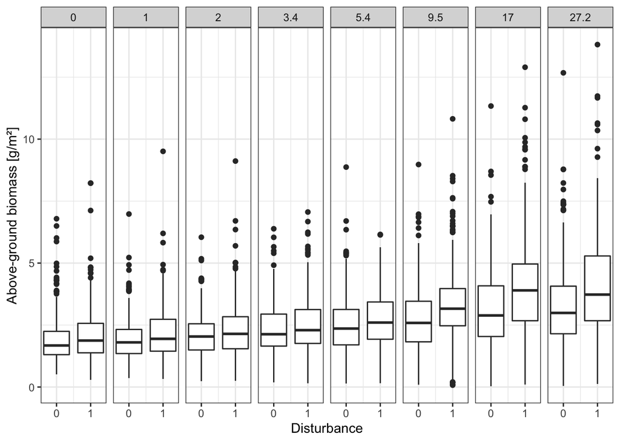

```r
library("ggplot2")
theme_set(theme_bw())


ggplot(aes(disk, mass.above, group = disk), data = seabloom) +
  geom_boxplot() +
  facet_grid( ~ nadd) +
  scale_x_continuous(breaks = c(0, 1)) +
  xlab("Disturbance") +
  ylab("Above-ground biomass [g/m²]")
```

It seems that the higher the amount of added nutrients, the higher the gap in above-ground biomass between the disturbed and undisturbed plots.

### Modeling the interaction

[figure not shown]

In regression, the interaction is represented by a coefficient that estimates the effect of the product of the two predictors. Let’s create this new variable and call it diskxnadd.

```r
seabloom$diskxnadd <- seabloom$disk * seabloom$nadd

int <- "mass.above ~ disk + nadd + diskxnadd"
fit.int <- sem(int, data = seabloom)
summary(fit.int)
```

```
## lavaan 0.6-12 ended normally after 1 iterations
##
##   Estimator                                         ML
##   Optimization method                           NLMINB
##   Number of model parameters                         4
##
##   Number of observations                          5040
##
## Model Test User Model:
##
##   Test statistic                                 0.000
##   Degrees of freedom                                 0
##
## Parameter Estimates:
##
##   Standard errors                             Standard
##   Information                                 Expected
##   Information saturated (h1) model          Structured
##
## Regressions:
##                    Estimate  Std.Err  z-value  P(>|z|)
##   mass.above ~
##     disk              0.203    0.053    3.841    0.000
##     nadd              0.052    0.003   17.536    0.000
##     diskxnadd         0.030    0.004    6.823    0.000
##
## Variances:
##                    Estimate  Std.Err  z-value  P(>|z|)
##    .mass.above        1.877    0.037   50.200    0.000
```

The results show a significant effect of both variables and their interaction.

Next, we model them as a composite:

```r
compint <-
"comp.int <~ 1 * disk + nadd + diskxnadd
mass.above ~ comp.int"

fit.compint <- sem(compint, data = seabloom)
summary(fit.compint, standardized = TRUE, rsq = TRUE)
```

```
## lavaan 0.6-12 ended normally after 19 iterations
##
##   Estimator                                         ML
##   Optimization method                           NLMINB
##   Number of model parameters                         4
##
##   Number of observations                          5040
##
## Model Test User Model:
##
##   Test statistic                                 0.000
##   Degrees of freedom                                 0
##
## Parameter Estimates:
##
##   Standard errors                             Standard
##   Information                                 Expected
##   Information saturated (h1) model          Structured
##
## Composites:
##                    Estimate  Std.Err  z-value  P(>|z|)   Std.lv  Std.all
##   comp.int <~
##     disk              1.000                               0.319    0.159
##     nadd              0.256    0.061    4.174    0.000    0.082    0.723
##     diskxnadd         0.147    0.055    2.663    0.008    0.047    0.340
##
## Regressions:
##                    Estimate  Std.Err  z-value  P(>|z|)   Std.lv  Std.all
##   mass.above ~
##     comp.int          0.203    0.053    3.841    0.000    0.635    0.421
##
## Variances:
##                    Estimate  Std.Err  z-value  P(>|z|)   Std.lv  Std.all
##    .mass.above        1.877    0.037   50.200    0.000    1.877    0.823
##     comp.int          0.000                               0.000    0.000
##
## R-Square:
##                    Estimate
##     mass.above        0.177
```

The combined effect of the predictors is the `std.all` value for the regression (0.421).

### Full model

```r
int.full <-
"comp.int <~ 1 * disk + nadd + diskxnadd

mass.above ~ comp.int + rich + even + precip.mm
rich ~ nadd + precip.mm
even ~ nadd + precip.mm

rich ~~ even"

fit.int.full <- sem(int.full, data = seabloom)
summary(fit.int.full, fit.measures = TRUE, standardized = TRUE, rsq = TRUE)
```

```
## lavaan 0.6-12 ended normally after 57 iterations
##
##   Estimator                                         ML
##   Optimization method                           NLMINB
##   Number of model parameters                        14
##
##   Number of observations                          5040
##
## Model Test User Model:
##
##   Test statistic                                29.074
##   Degrees of freedom                                 4
##   P-value (Chi-square)                           0.000
##
## Model Test Baseline Model:
##
##   Test statistic                              5206.853
##   Degrees of freedom                                15
##   P-value                                        0.000
##
## User Model versus Baseline Model:
##
##   Comparative Fit Index (CFI)                    0.995
##   Tucker-Lewis Index (TLI)                       0.982
##
## Loglikelihood and Information Criteria:
##
##   Loglikelihood user model (H0)             -20097.844
##   Loglikelihood unrestricted model (H1)     -20083.307
##
##   Akaike (AIC)                               40223.689
##   Bayesian (BIC)                             40315.041
##   Sample-size adjusted Bayesian (BIC)        40270.554
##
## Root Mean Square Error of Approximation:
##
##   RMSEA                                          0.035
##   90 Percent confidence interval - lower         0.024
##   90 Percent confidence interval - upper         0.048
##   P-value RMSEA <= 0.05                          0.974
```

[output cut: 34 more lines]

```
##  .rich ~~
##    .even             -0.416    0.012  -35.259    0.000   -0.416   -0.572
##
## Variances:
##                    Estimate  Std.Err  z-value  P(>|z|)   Std.lv  Std.all
##    .mass.above        1.645    0.033   50.200    0.000    1.645    0.720
##    .rich             13.334    0.266   50.200    0.000   13.334    0.809
##    .even              0.040    0.001   50.200    0.000    0.040    0.912
##     comp.int          0.000                               0.000    0.000
##
## R-Square:
##                    Estimate
##     mass.above        0.280
##     rich              0.191
##     even              0.088
```

Not the greatest fit in terms of $p$-value (0), but really fine in terms of CFI (0.995).

## Multigroup fitting

Another way to incorporate interactions is to fit SEMs where coefficients can vary among groups. Lavaan offers the “group” argument to specify for which groups coefficients should be estimated. Importantly, groups have to be of categorical nature. For our dataset, the application of the disturbance (“yes” vs “no”) is categorical. So let’s fit the SEM to the two disturbance regimes:

```r
int.mg <-
"mass.above ~ rich + even + precip.mm
rich ~ nadd + precip.mm
even ~ nadd + precip.mm

rich ~~ even"

fit.int.mg <- sem(int.mg, group = "disk", data = seabloom)
summary(fit.int.mg, standardized = TRUE, rsq = TRUE)
```

```
## lavaan 0.6-12 ended normally after 91 iterations
##
##   Estimator                                         ML
##   Optimization method                           NLMINB
##   Number of model parameters                        28
##
##   Number of observations per group:
##     0                                             2736
##     1                                             2304
##
## Model Test User Model:
##
##   Test statistic                              1275.898
##   Degrees of freedom                                 2
##   P-value (Chi-square)                           0.000
##   Test statistic for each group:
##     0                                          504.856
##     1                                          771.042
##
## Parameter Estimates:
##
##   Standard errors                             Standard
##   Information                                 Expected
##   Information saturated (h1) model          Structured
##
##
## Group 1 [0]:
##
## Regressions:
##                    Estimate  Std.Err  z-value  P(>|z|)   Std.lv  Std.all
##   mass.above ~
##     rich             -0.004    0.008   -0.506    0.613   -0.004   -0.012
##     even             -0.936    0.160   -5.837    0.000   -0.936   -0.142
##     precip.mm         0.089    0.015    5.833    0.000    0.089    0.111
##   rich ~
##     nadd             -0.168    0.008  -22.276    0.000   -0.168   -0.387
##     precip.mm         0.363    0.041    8.948    0.000    0.363    0.155
##   even ~
##     nadd              0.004    0.000    9.873    0.000    0.004    0.183
##     precip.mm        -0.021    0.002   -9.572    0.000   -0.021   -0.177
```

[output cut: 47 more lines]

```
##    .mass.above        1.576    0.222    7.087    0.000    1.576    0.939
##    .rich              5.033    0.403   12.490    0.000    5.033    1.173
##    .even              0.554    0.022   25.597    0.000    0.554    2.539
##
## Variances:
##                    Estimate  Std.Err  z-value  P(>|z|)   Std.lv  Std.all
##    .mass.above        2.683    0.079   33.941    0.000    2.683    0.952
##    .rich             14.528    0.428   33.941    0.000   14.528    0.789
##    .even              0.042    0.001   33.941    0.000    0.042    0.880
##
## R-Square:
##                    Estimate
##     mass.above        0.048
##     rich              0.211
##     even              0.120
```

The default option is to let all coefficients vary between groups, but have the same structure of direct and indirect effects. Let’s visualize the estimated coefficients:

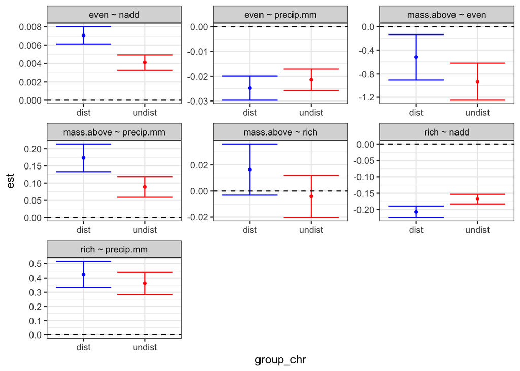

```r
fit_tab <- (summary(fit.int.mg, standardized = TRUE, rsq = TRUE))$pe
fit_tab$term <- paste0(fit_tab$lhs, " ", fit_tab$op, " ", fit_tab$rhs)
fit_tab$group_chr <- ifelse(fit_tab$group == 1, "undist",
                            ifelse(fit_tab$group == 2, "dist", NA))

ggplot(data=subset(fit_tab, op == "~"), aes(y=est, x=group_chr, colour=group_chr)) +
  geom_point(size=1) + geom_errorbar(aes(ymin = est-se*1.96, ymax = est+se*1.96)) +
  facet_wrap(~term, scales="free") +
  scale_colour_manual(values = c("blue",  "red")) +
  geom_hline(aes(yintercept = 0), colour = "black", linetype = "dashed") +
  guides(colour="none") +
  theme_bw()
```

Each facet grid shows a path and the estimated coefficients, one for disturbed (in blue) and one for the undisturbed plots (in red).

To test equality constraints, such as same means of coefficients among groups, lavaan offers the “group.equal” argument:

```r
group.equal=c(
"intercepts",
"means",
"regressions",
"residuals",
"residual.covariances")

#fit.int.mg <- sem(int.mg, group = "disk", group.equal = c("regressions"), data = seabloom)
```

Furthermore, we can test equality constraints by labeling parameters. To do so, we provide namees for the path coefficients that we want to be equal for both groups (e.g. “b1”), whereas path coefficients that we want to vary between groups have different names (e.g., “b4a” and “b4b”).

```r
int.mg.constrain <-
"mass.above ~  c('b1', 'b1') * rich + c('b2', 'b2') * even + c('b3', 'b3') * precip.mm
rich ~ c('b4a', 'b4b') * nadd + c('b5', 'b5') * precip.mm
even ~ c('b6a', 'b6b') *  nadd + c('b7', 'b7') * precip.mm

rich ~~ even"

fit.int.mg.constrain <- sem(int.mg.constrain, group = "disk", data = seabloom)
summary(fit.int.mg.constrain, standardized = TRUE, rsq = TRUE)
```

```
## lavaan 0.6-12 ended normally after 69 iterations
##
##   Estimator                                         ML
##   Optimization method                           NLMINB
##   Number of model parameters                        28
##   Number of equality constraints                     5
##
##   Number of observations per group:
##     0                                             2736
##     1                                             2304
##
## Model Test User Model:
##
##   Test statistic                              1291.423
##   Degrees of freedom                                 7
##   P-value (Chi-square)                           0.000
##   Test statistic for each group:
##     0                                          510.685
##     1                                          780.737
##
## Parameter Estimates:
##
##   Standard errors                             Standard
##   Information                                 Expected
##   Information saturated (h1) model          Structured
##
##
## Group 1 [0]:
##
## Regressions:
##                    Estimate  Std.Err  z-value  P(>|z|)   Std.lv  Std.all
##   mass.above ~
##     rich      (b1)    0.004    0.006    0.683    0.495    0.004    0.013
##     even      (b2)   -0.771    0.125   -6.188    0.000   -0.771   -0.116
##     precp.mm  (b3)    0.119    0.012    9.725    0.000    0.119    0.148
##   rich ~
##     nadd     (b4a)   -0.168    0.008  -22.274    0.000   -0.168   -0.386
##     precp.mm  (b5)    0.391    0.031   12.784    0.000    0.391    0.167
##   even ~
##     nadd     (b6a)    0.004    0.000    9.872    0.000    0.004    0.182
```

[output cut: 48 more lines]

```
##    .mass.above        2.213    0.139   15.912    0.000    2.213    1.327
##    .rich              5.322    0.277   19.243    0.000    5.322    1.243
##    .even              0.539    0.015   35.786    0.000    0.539    2.474
##
## Variances:
##                    Estimate  Std.Err  z-value  P(>|z|)   Std.lv  Std.all
##    .mass.above        2.694    0.079   33.941    0.000    2.694    0.969
##    .rich             14.532    0.428   33.941    0.000   14.532    0.792
##    .even              0.042    0.001   33.941    0.000    0.042    0.885
##
## R-Square:
##                    Estimate
##     mass.above        0.031
##     rich              0.208
##     even              0.115
```

Let’s visualize again the coefficients to see the effect:

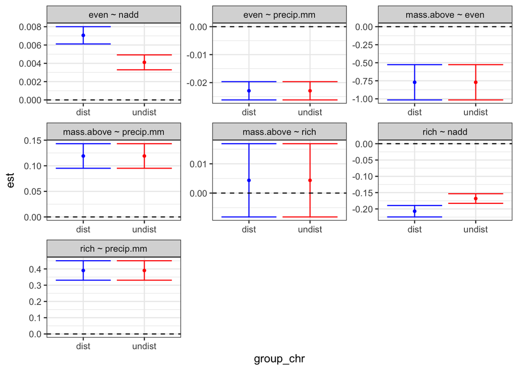

```r
fit_tab <- (summary(fit.int.mg.constrain, standardized = TRUE, rsq = TRUE))$pe
fit_tab$term <- paste0(fit_tab$lhs, " ", fit_tab$op, " ", fit_tab$rhs)
fit_tab$group_chr <- ifelse(fit_tab$group == 1, "undist",
                            ifelse(fit_tab$group == 2, "dist", NA))

ggplot(data=subset(fit_tab, op == "~"), aes(y=est, x=group_chr, colour=group_chr)) +
  geom_point(size=1) + geom_errorbar(aes(ymin = est-se*1.96, ymax = est+se*1.96)) +
  facet_wrap(~term, scales="free") +
  scale_colour_manual(values = c("blue",  "red")) +
  geom_hline(aes(yintercept = 0), colour = "black", linetype = "dashed") +
  guides(colour="none") +
  theme_bw()
```

Model comparison with AICc indicates that the disturbance effect probably interacts with more than the nitrogen addition.

```r
library(AICcmodavg)
aictab(list(fit.int.mg, fit.int.mg.constrain))
```

```
##
## Model selection based on AICc:
##
##       K     AICc Delta_AICc AICcWt Cum.Wt        LL
## Mod1 28 41331.61       0.00   0.93   0.93 -20637.50
## Mod2 23 41336.94       5.33   0.07   1.00 -20645.27
```

# Complex sampling structure

Often, we encounter more complex sampling or experimental schemes, e.g. the data is nested within sites or contains groups with non-random differences such as sexes or lifestages. As a result, these data violate the principle of being [*i.i.d.* (independent and identically distributed)](https://en.wikipedia.org/wiki/Independent_and_identically_distributed_random_variables). Thus, it is necessary to account for this structure in the data in the model.

The add-on package [`lavaan.survey`](https://cran.r-project.org/web/packages/lavaan.survey/index.html) allows the analysis of stratified, clustered or weighted data with the help of the package [`survey`](https://r-survey.r-forge.r-project.org/survey/). With this, `lavaan` objects can be processed further with a specific data structure: first, we initialize the design and then, post-process the `lavaan` object and compute the adjusted results. The result is a corrected `lavaan` object.

```r
library("lavaan.survey")
```

```r
design <- svydesign(ids = ~ plot, strata = ~ field, nest = TRUE,
                    data = seabloom)
summary(design)
```

```
## Stratified 1 - level Cluster Sampling design (with replacement)
## With (158) clusters.
## svydesign(ids = ~plot, strata = ~field, nest = TRUE, data = seabloom)
## Probabilities:
##    Min. 1st Qu.  Median    Mean 3rd Qu.    Max.
##       1       1       1       1       1       1
## Stratum Sizes:
##               A    B    C
## obs        1608 1824 1608
## design.PSU   53   53   52
## actual.PSU   53   53   52
## Data variables:
##  [1] "exp"          "field"        "plot"         "disk"         "yr.plowed"
##  [6] "ntrt"         "nadd"         "other.add"    "year"         "dur"
## [11] "precip.mm"    "precip.gs"    "mass.above"   "rich"         "even"
## [16] "ens.pie"      "even.rev"     "rich_std"     "even.rev_std" "landuse"
## [21] "diskxnadd"
```

Next, we can refit the `simple` model from before with `lavaan.survey` using the specified study design as an argument.

```r
fit.simple.nest <- lavaan.survey(lavaan.fit = fit.simple,
                                 survey.design = design)
summary(fit.simple.nest, rsq = TRUE)
```

```
## lavaan 0.6-12 ended normally after 50 iterations
##
##   Estimator                                         ML
##   Optimization method                           NLMINB
##   Number of model parameters                        16
##
##   Number of observations                          5040
##
## Model Test User Model:
##                                               Standard      Robust
##   Test Statistic                                 6.684       1.470
##   Degrees of freedom                                 2           2
##   P-value (Chi-square)                           0.035       0.480
##   Scaling correction factor                                  4.548
##     Satorra-Bentler correction
##
## Parameter Estimates:
##
##   Standard errors                           Robust.sem
##   Information                                 Expected
##   Information saturated (h1) model          Structured
##
## Regressions:
##                    Estimate  Std.Err  z-value  P(>|z|)
##   mass.above ~
##     nadd              0.085    0.008   10.431    0.000
##     disk              0.424    0.103    4.104    0.000
##     rich              0.086    0.011    7.770    0.000
##     even             -0.651    0.140   -4.647    0.000
##     precip.mm         0.099    0.007   14.539    0.000
##   rich ~
##     nadd             -0.186    0.018  -10.287    0.000
##     precip.mm         0.393    0.016   25.201    0.000
##   even ~
##     nadd              0.005    0.001    7.229    0.000
##     precip.mm        -0.023    0.001  -16.292    0.000
##
## Covariances:
##                    Estimate  Std.Err  z-value  P(>|z|)
##  .rich ~~
##    .even             -0.416    0.014  -29.235    0.000
##
## Intercepts:
##                    Estimate  Std.Err  z-value  P(>|z|)
##    .mass.above        0.645    0.183    3.517    0.000
##    .rich              5.016    0.258   19.431    0.000
##    .even              0.552    0.014   38.642    0.000
##
## Variances:
##                    Estimate  Std.Err  z-value  P(>|z|)
##    .mass.above        1.669    0.092   18.204    0.000
##    .rich             13.334    0.595   22.418    0.000
##    .even              0.040    0.001   31.235    0.000
##
## R-Square:
##                    Estimate
##     mass.above        0.267
##     rich              0.191
##     even              0.088
```

# References

Bollen, Kenneth A. 1989. *Structural Equations with Latent Variables*. USA: John Wiley & Sons.

Grace, James B. 2021. “Quantitative Analysis Using Structural Equation Modeling.” 2021. https://www.usgs.gov/centers/wetland-and-aquatic-research-center/science/quantitative-analysis-using-structural-equation?qt-science_center_objects=0#qt-science_center_objects.

Grace, James B., T. Michael Anderson, Han Olff, and Samuel M. Scheiner. 2010. “On the Specification of Structural Equation Models for Ecological Systems.” *Ecological Monographs* 80 (1): 67–87. http://www.jstor.org/stable/27806874.

Grace, James B, and Kenneth A. Bollen. 2008. “Representing General Theoretical Concepts in Structural Equation Models: The Role of Composite Variables.” *Environmental and Ecological Statistics* 15: 191–213. https://doi.org/https://doi.org/10.1007/s10651-007-0047-7.

Grace, James B, and Magdalena Steiner. 2021. “A Protocol for Modelling Generalised Biological Responses Using Latent Variables in Structural Equation Models.” *One Ecosystem* 6: e67320. https://doi.org/10.3897/oneeco.6.e67320.

Seabloom, Eric W., Elizabeth T. Borer, and David Tilman. 2020. “Grassland Ecosystem Recovery After Soil Disturbance Depends on Nutrient Supply Rate.” *Ecology Letters* 23 (12): 1756–65. https://doi.org/https://doi.org/10.1111/ele.13591.

[^1]: Indicator variables are observed/manifest variables that are linked to either a latent or composite variable.